# US_College_Analysis

aa2569@scarletmail.rutgers.edu

4/17/2023

## Loading the Dataset

```r
library(readr)
library(MVA)
```

```r
library(HSAUR2)
library(SciViews)
library(scatterplot3d)
library(car)
library(lattice)
library(GGally)
library(ggplot2)
library(ggridges)
library(ggvis)
library(ggthemes)
library(cowplot)
library(gapminder)
library(gganimate)
library(dplyr)
library(tidyverse)
library(grid)
library(gridExtra)
library(RColorBrewer)
library(Hotelling)
library(stats)
library(biotools)
library(factoextra)
library(FactoMineR)
library(ggfortify)
library(psych)
library(corrplot)
library(devtools)
library(cluster)
library(magrittr)
library(NbClust)
library(MASS)
library(gvlma)
library(leaps)
library(relaimpo)
library(e1071)
library(pROC)
library(memisc)
library(ROCR)
library(klaR)
library(caret)
library(caTools)

clg <- read.csv("/Users/ajayvishnu/Desktop/RUTGERS/Spring_2023/Multivariate Analysis/Datasets/College_Data.csv", row.names = 1)


attach(clg)
```

- The dataset is obtained from Kaggle: https://www.kaggle.com/datasets/yashgpt/us-college-data
- It has 777 colleges as rows and 18 columns defining various aspects for each college.

## QUESTIONS

#### Based on the given variables, can we classify the colleges based on their type (Public/Private)?

#### Based on the given variables, can we predict the type of the college?

## Analysing the Data

```r
str(clg)
```

```
## 'data.frame':    777 obs. of  18 variables:
##  $ Private    : int  1 1 1 1 1 1 1 1 1 1 ...
##  $ Apps       : int  1660 2186 1428 417 193 587 353 1899 1038 582 ...
##  $ Accept     : int  1232 1924 1097 349 146 479 340 1720 839 498 ...
##  $ Enroll     : int  721 512 336 137 55 158 103 489 227 172 ...
##  $ Top10perc  : int  23 16 22 60 16 38 17 37 30 21 ...
##  $ Top25perc  : int  52 29 50 89 44 62 45 68 63 44 ...
##  $ F.Undergrad: int  2885 2683 1036 510 249 678 416 1594 973 799 ...
##  $ P.Undergrad: int  537 1227 99 63 869 41 230 32 306 78 ...
##  $ Outstate   : int  7440 12280 11250 12960 7560 13500 13290 13868 15595 10468 ...
##  $ Room.Board : int  3300 6450 3750 5450 4120 3335 5720 4826 4400 3380 ...
##  $ Books      : int  450 750 400 450 800 500 500 450 300 660 ...
##  $ Personal   : int  2200 1500 1165 875 1500 675 1500 850 500 1800 ...
##  $ PhD        : int  70 29 53 92 76 67 90 89 79 40 ...
##  $ Terminal   : int  78 30 66 97 72 73 93 100 84 41 ...
##  $ S.F.Ratio  : num  18.1 12.2 12.9 7.7 11.9 9.4 11.5 13.7 11.3 11.5 ...
##  $ perc.alumni: int  12 16 30 37 2 11 26 37 23 15 ...
##  $ Expend     : int  7041 10527 8735 19016 10922 9727 8861 11487 11644 8991 ...
##  $ Grad.Rate  : int  60 56 54 59 15 55 63 73 80 52 ...
```

- The first column showing if the college is Private or Public has been changed manually. (1 - Private, 0 - Public)
- In this analysis, we try to determine if we are able to classify between Public and Private colleges based on the given data, and also if we can predict the type of university based on the rest of the variables in the data.

### Data Dictionary

- Group: A categorical variable indicating whether the college is public or private. 1 indicates a private college and 0 indicates a public college.
- Private: A binary variable indicating whether the college is private or not. 1 indicates a private college and 0 indicates a public college.
- Apps: The total number of applications received by the college.
- Accept: The total number of applications accepted by the college.
- Enroll: The total number of students enrolled in the college.
- Top10perc: The percentage of new students who ranked in the top 10% of their high school class.
- Top25perc: The percentage of new students who ranked in the top 25% of their high school class.
- F.Undergrad: The total number of full-time undergraduate students enrolled in the college.
- P.Undergrad: The total number of part-time undergraduate students enrolled in the college.
- Outstate: The out-of-state tuition fee for the college.
- Room.Board: The cost of room and board for the college.
- Books: The estimated cost of books and supplies for a year of study.
- Personal: The estimated personal expenses for a year of study.
- PhD: The percentage of faculty members who hold a PhD degree.
- Terminal: The percentage of faculty members who hold a terminal degree in their field of study.
- S.F.Ratio: The student-to-faculty ratio for the college.
- perc.alumni: The percentage of alumni who donate to the college.
- Expend: The instructional expenditure per student at the college.
- Grad.Rate: The graduation rate of the college as a percentage.

### Correlation Test

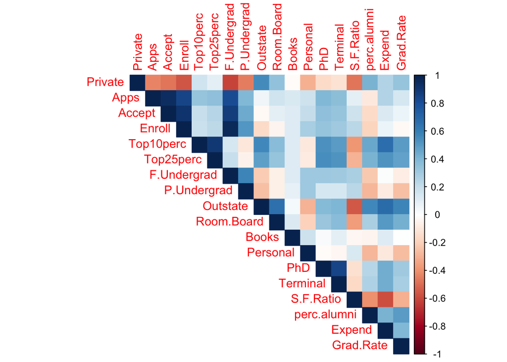

```r
corrplot(cor(clg), type = "upper", method = "color")
```

- The correlation matrix shows us that there is correlation between the columns.
- Hence, Principal Component Analysis (PCA) can be used to reduce the number of columns for the analysis.

## Principal Component Analysis (PCA)

###PCA

```r
clg_pca <- prcomp(clg[,-1],scale=TRUE)
```

- We have excluded Column 1 which is Public/Private as we are trying answer the question on how to classify these colleges.

### Scree diagram

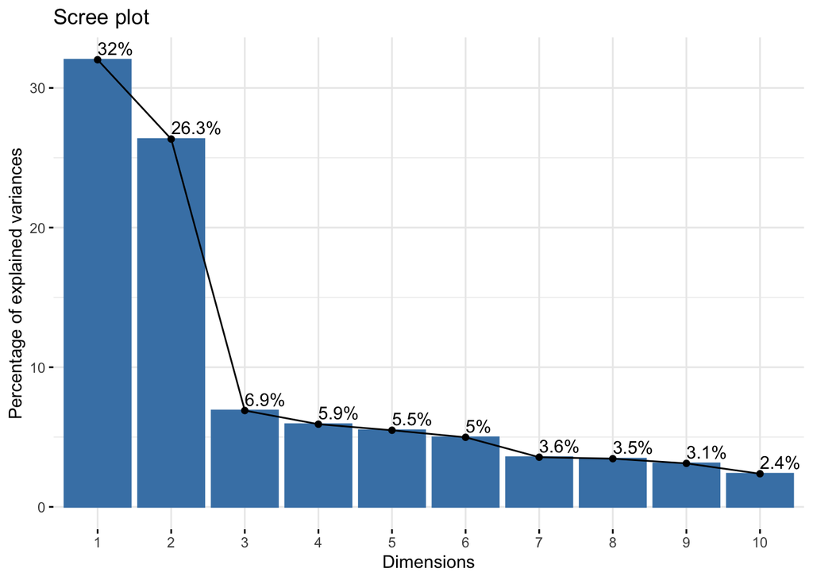

```r
fviz_eig(clg_pca, addlabels = TRUE)
```

- The scree diagram shows us that sum of the first 2 principal components is less than 70%.
- So, we cannot move forward using PCA for column reduction.
- We now move on to check Exploratory Factor Analysis (EFA).

## Exploratory Factor Analysis (EFA)

### EFA

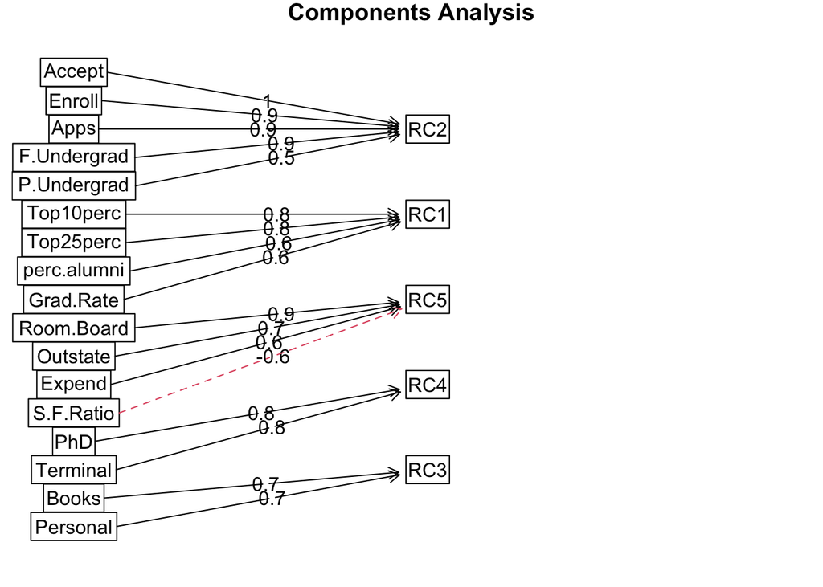

```r
fit.pc <- principal(clg[,-1], nfactors=5, rotate="varimax")
fa.diagram(fit.pc)
```

### Defining the factors obtained

##### RC2 - Student numbers

- RC2 pertains the Applications, Acceptances, Enrollments, Number of full time and part time undergraduate students.
- This summarises that RC2 is taking the number of students count in a broader picture.

##### RC1 - Student merit

- RC1 summarize the percentage of students who ranked 10%, 25% in their high school, the Graduation Rate of the college.
- This shows that this factor is defined by the merit of the student.

##### RC5 - Educational/College Expenses

- RC5 caters to Outstate tuition expenses, Room and Board expenses, and the instructional expenses per each student.
- So, this can be defined as the educational expenses incurred by student.

##### RC4 - Faculty qualification

- RC4 sums up the educational qualification of the faculty at the colleges.
- It defines if the faculty hold a PhD or a terminal degree.

##### RC3 - Student Expenses

- RC3 gathers the details of the expenses incurred for books and personal expenses of the students.
- It summarises the personal expenses the student spends on their development.

### Reducing the existing variables and using factors for further analysis

```r
efa_data <- as.data.frame(fit.pc$scores)
```

## Clustering

### Distance matrix

```r
clg_dist <- get_dist(efa_data, stand = TRUE, method = "euclidean")
```

- We consider the factors from EFA instead of the original dataset variables for the cluster analysis.

### Kmeans optimal clusters

```r
set.seed(123)
matstd_clg <- scale(efa_data)
```

- We scale the data to consider for identifying the optimal number of clusters.

### Code for running without error

```r
fviz_nbclust <- function (x, FUNcluster = NULL, method = c("silhouette", "wss",
                                                           "gap_stat"), diss = NULL, k.max = 10, nboot = 100, verbose = interactive(),
                          barfill = "steelblue", barcolor = "steelblue", linecolor = "steelblue",
                          print.summary = TRUE, ...)
{
  set.seed(1111)
  if (k.max < 2)
    stop("k.max must bet > = 2")
  method = match.arg(method)
  if (!inherits(x, c("data.frame", "matrix")) & !("Best.nc" %in%
                                                  names(x)))
    stop("x should be an object of class matrix/data.frame or ",
         "an object created by the function NbClust() [NbClust package].")
  if (inherits(x, "list") & "Best.nc" %in% names(x)) {
    best_nc <- x$Best.nc
    if (any(class(best_nc) == "numeric") )
      print(best_nc)
    else if (any(class(best_nc) == "matrix") )
      .viz_NbClust(x, print.summary, barfill, barcolor)
  }
  else if (is.null(FUNcluster))
    stop("The argument FUNcluster is required. ", "Possible values are kmeans, pam, hcut, clara, ...")
  else if (!is.function(FUNcluster)) {
    stop("The argument FUNcluster should be a function. ",
         "Check if you're not overriding the specified function name somewhere.")
  }
  else if (method %in% c("silhouette", "wss")) {
    if (is.data.frame(x))
      x <- as.matrix(x)
    if (is.null(diss))
      diss <- stats::dist(x)
    v <- rep(0, k.max)
    if (method == "silhouette") {
      for (i in 2:k.max) {
        clust <- FUNcluster(x, i, ...)
        v[i] <- .get_ave_sil_width(diss, clust$cluster)
      }
    }
    else if (method == "wss") {
      for (i in 1:k.max) {
        clust <- FUNcluster(x, i, ...)
        v[i] <- .get_withinSS(diss, clust$cluster)
      }
    }
    df <- data.frame(clusters = as.factor(1:k.max), y = v,
                     stringsAsFactors = TRUE)
    ylab <- "Total Within Sum of Square"
    if (method == "silhouette")
      ylab <- "Average silhouette width"
    p <- ggpubr::ggline(df, x = "clusters", y = "y", group = 1,
                        color = linecolor, ylab = ylab, xlab = "Number of clusters k",
                        main = "Optimal number of clusters")
    if (method == "silhouette")
      p <- p + geom_vline(xintercept = which.max(v), linetype = 2,
                          color = linecolor)
    return(p)
  }
  else if (method == "gap_stat") {
    extra_args <- list(...)
    gap_stat <- cluster::clusGap(x, FUNcluster, K.max = k.max,
                                 B = nboot, verbose = verbose, ...)
    if (!is.null(extra_args$maxSE))
      maxSE <- extra_args$maxSE
    else maxSE <- list(method = "firstSEmax", SE.factor = 1)
    p <- fviz_gap_stat(gap_stat, linecolor = linecolor,
                       maxSE = maxSE)
    return(p)
  }
}

.viz_NbClust <- function (x, print.summary = TRUE, barfill = "steelblue",
                          barcolor = "steelblue")
{
  best_nc <- x$Best.nc
  if (any(class(best_nc) == "numeric") )
    print(best_nc)
  else if (any(class(best_nc) == "matrix") ) {
    best_nc <- as.data.frame(t(best_nc), stringsAsFactors = TRUE)
    best_nc$Number_clusters <- as.factor(best_nc$Number_clusters)
    if (print.summary) {
      ss <- summary(best_nc$Number_clusters)
      cat("Among all indices: \n===================\n")
      for (i in 1:length(ss)) {
        cat("*", ss[i], "proposed ", names(ss)[i],
            "as the best number of clusters\n")
      }
      cat("\nConclusion\n=========================\n")
      cat("* According to the majority rule, the best number of clusters is ",
          names(which.max(ss)), ".\n\n")
    }
    df <- data.frame(Number_clusters = names(ss), freq = ss,
                     stringsAsFactors = TRUE)
    p <- ggpubr::ggbarplot(df, x = "Number_clusters",
                           y = "freq", fill = barfill, color = barcolor) +
      labs(x = "Number of clusters k", y = "Frequency among all indices",
           title = paste0("Optimal number of clusters - k = ",
                          names(which.max(ss))))
    return(p)
  }
}
```

### Test for optimal clusters

```r
res.nbclust <- efa_data %>% scale() %>% NbClust(distance = "euclidean", min.nc = 2, max.nc = 10, method = "complete", index ="all")
```

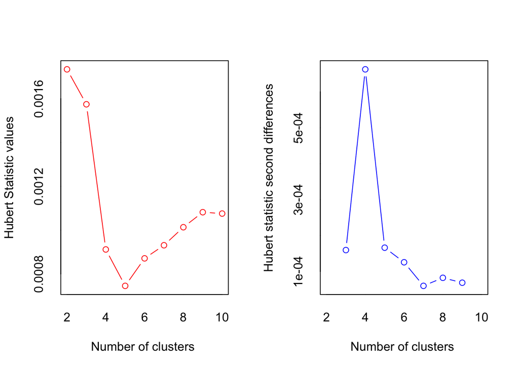

```
## *** : The Hubert index is a graphical method of determining the number of clusters.
##                 In the plot of Hubert index, we seek a significant knee that corresponds to a
##                 significant increase of the value of the measure i.e the significant peak in Hubert
##                 index second differences plot.
##
```

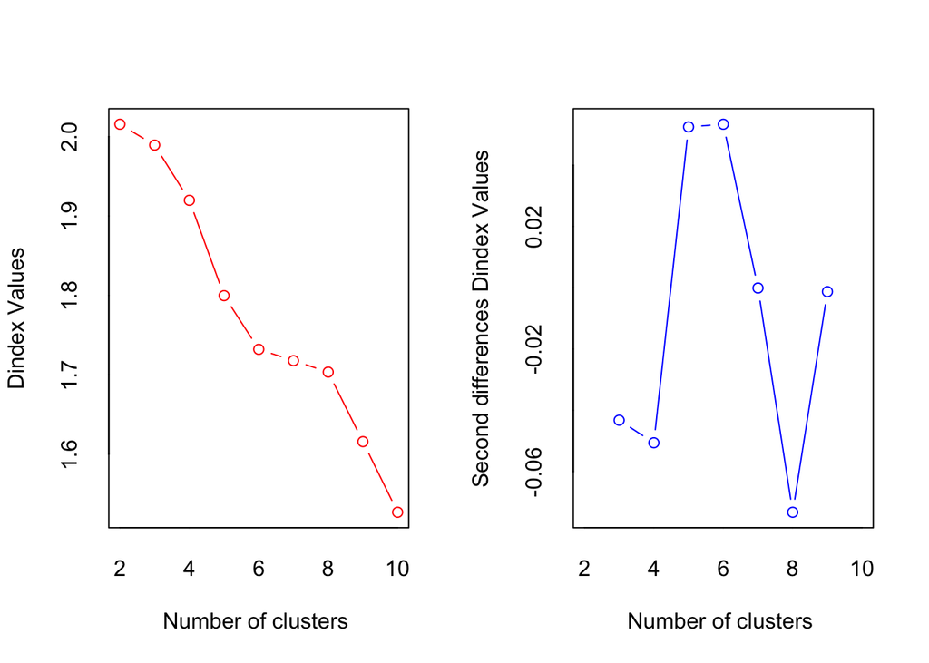

```
## *** : The D index is a graphical method of determining the number of clusters.
##                 In the plot of D index, we seek a significant knee (the significant peak in Dindex
##                 second differences plot) that corresponds to a significant increase of the value of
##                 the measure.
##
## * Among all indices:
## * 10 proposed 2 as the best number of clusters
## * 3 proposed 3 as the best number of clusters
## * 2 proposed 5 as the best number of clusters
## * 4 proposed 6 as the best number of clusters
## * 1 proposed 8 as the best number of clusters
## * 1 proposed 9 as the best number of clusters
## * 3 proposed 10 as the best number of clusters
##
##                    ***** Conclusion *****
##
## * According to the majority rule, the best number of clusters is  2
##
##
```

```
## Among all indices:
## ===================
## * 2 proposed  0 as the best number of clusters
## * 10 proposed  2 as the best number of clusters
## * 3 proposed  3 as the best number of clusters
## * 2 proposed  5 as the best number of clusters
## * 4 proposed  6 as the best number of clusters
## * 1 proposed  8 as the best number of clusters
## * 1 proposed  9 as the best number of clusters
## * 3 proposed  10 as the best number of clusters
##
## Conclusion
## =========================
## * According to the majority rule, the best number of clusters is  2 .
```

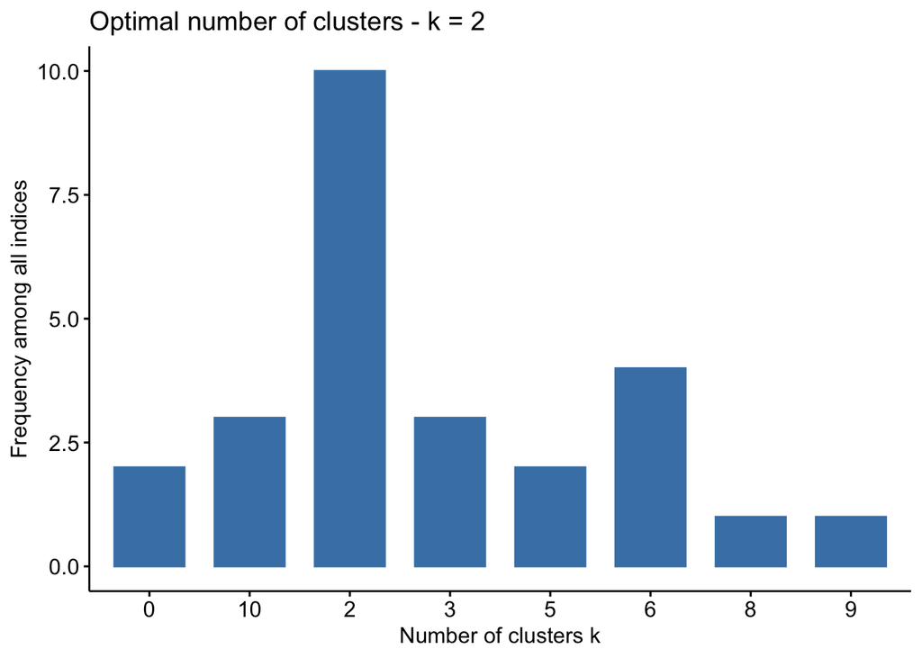

```r
fviz_nbclust(res.nbclust, ggtheme = theme_minimal())
```

- This test shows the optimal number of clusters is 2, which makes sense as we would like to check if the college is Private or Public.
- We now try to visualize the clusters for the colleges and see if we can classify them based on the Type of the college (Private/Public)

### Cluster plot with 2 clusters

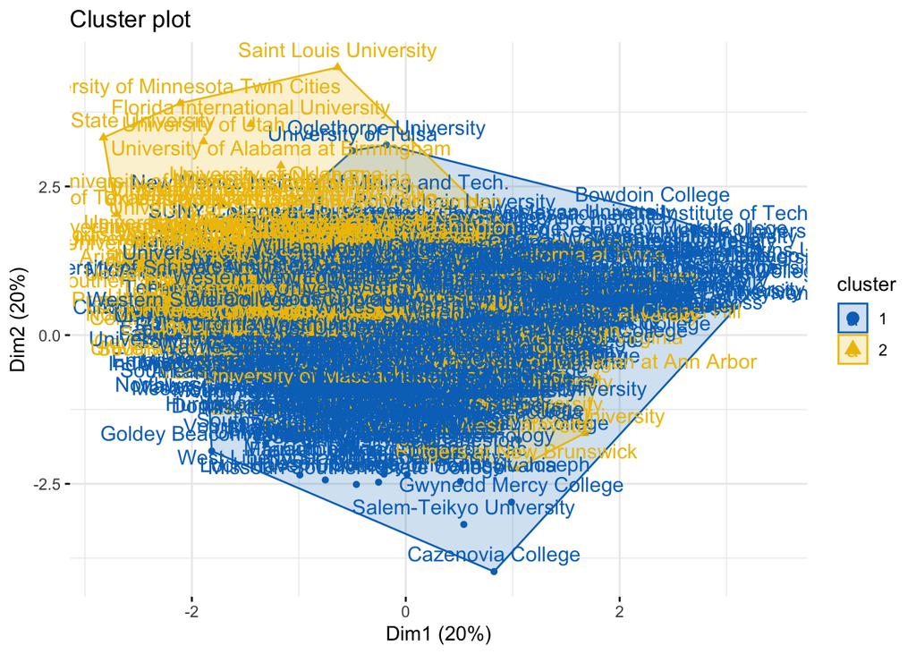

```r
set.seed(1111)
km.res <- kmeans(matstd_clg, 2, nstart = 25)
# Visualize
fviz_cluster(km.res, data = matstd_clg,
             ellipse.type = "convex",
             palette = "jco",
             ggtheme = theme_minimal())
```

- As there are 777 colleges, the cluster plot looks very messy.
- We can try to generate a confusion matrix for the above analysis and see the results more clearly.

### Confusion Matrix & Accuracy

```r
Clustered <- ifelse(km.res$cluster > 1.5, "Public", "Private")
Actual <- ifelse(clg$Private == 1, "Private", "Public")
confusion_mat <- table(Clustered, Actual)
confusion_mat
```

```
##          Actual
## Clustered Private Public
##   Private     550     71
##   Public       15    141
```

- The confusion matrix gives us a better understanding of how the actual type of college is clustered.
- We see that colleges have been clustered not to 100% accuracy. There are disruptions and we can check how accurate we are.

```r
accuracy <- sum(diag(confusion_mat)) / sum(confusion_mat)
cat("Accuracy:", round(accuracy, 3), "\n")
```

```
## Accuracy: 0.889
```

- We see that the clustering has classified the colleges with 88.9% accuracy.
- We can consider this as good outcome as the accuracy is close to 90%.
- We can conclude that we can classify the type of college based on the data provided.
- Further, we check if we can predict the type of college based on the inputs provided.

## Logistic Regression

```r
str(clg)
```

```
## 'data.frame':    777 obs. of  18 variables:
##  $ Private    : int  1 1 1 1 1 1 1 1 1 1 ...
##  $ Apps       : int  1660 2186 1428 417 193 587 353 1899 1038 582 ...
##  $ Accept     : int  1232 1924 1097 349 146 479 340 1720 839 498 ...
##  $ Enroll     : int  721 512 336 137 55 158 103 489 227 172 ...
##  $ Top10perc  : int  23 16 22 60 16 38 17 37 30 21 ...
##  $ Top25perc  : int  52 29 50 89 44 62 45 68 63 44 ...
##  $ F.Undergrad: int  2885 2683 1036 510 249 678 416 1594 973 799 ...
##  $ P.Undergrad: int  537 1227 99 63 869 41 230 32 306 78 ...
##  $ Outstate   : int  7440 12280 11250 12960 7560 13500 13290 13868 15595 10468 ...
##  $ Room.Board : int  3300 6450 3750 5450 4120 3335 5720 4826 4400 3380 ...
##  $ Books      : int  450 750 400 450 800 500 500 450 300 660 ...
##  $ Personal   : int  2200 1500 1165 875 1500 675 1500 850 500 1800 ...
##  $ PhD        : int  70 29 53 92 76 67 90 89 79 40 ...
##  $ Terminal   : int  78 30 66 97 72 73 93 100 84 41 ...
##  $ S.F.Ratio  : num  18.1 12.2 12.9 7.7 11.9 9.4 11.5 13.7 11.3 11.5 ...
##  $ perc.alumni: int  12 16 30 37 2 11 26 37 23 15 ...
##  $ Expend     : int  7041 10527 8735 19016 10922 9727 8861 11487 11644 8991 ...
##  $ Grad.Rate  : int  60 56 54 59 15 55 63 73 80 52 ...
```

- The str function shows the data types of each of the variable
- Here, we want to predict if the college is Public or Private based on the variables in other columns.
- For this, we create a training and testing sets as below.

### Defining training and testing sets

```r
set.seed(1234)
split = sample.split(clg$Private, SplitRatio = 0.70)
train = subset(clg, split == TRUE)
test = subset(clg, split == FALSE)

Xtrain <- train[,2:18]
Ytrain <- train[,1]

Xtest <- test[,2:18]
```

- 70% of the data is selected for training and the rest 30% for testing our regression.
- The first column (College Type) is used as Ytrain which is our response variable.

### Performing Regression

```r
x <- cbind(Xtrain,Ytrain)
logistic <- glm(Ytrain ~ ., data = x,family='binomial')
summary(logistic)
```

```
##
## Call:
## glm(formula = Ytrain ~ ., family = "binomial", data = x)
##
## Deviance Residuals:
##     Min       1Q   Median       3Q      Max
## -3.7422  -0.0422   0.0462   0.1673   3.1599
##
## Coefficients:
##               Estimate Std. Error z value Pr(>|z|)
## (Intercept) -0.5676725  2.1562290  -0.263   0.7923
## Apps        -0.0007502  0.0003174  -2.363   0.0181 *
## Accept       0.0002637  0.0005422   0.486   0.6267
## Enroll       0.0012106  0.0008669   1.396   0.1626
## Top10perc    0.0164093  0.0317300   0.517   0.6050
## Top25perc    0.0092338  0.0213646   0.432   0.6656
## F.Undergrad -0.0002595  0.0001415  -1.835   0.0666 .
## P.Undergrad -0.0001175  0.0001842  -0.638   0.5237
## Outstate     0.0005294  0.0001204   4.399 1.09e-05 ***
## Room.Board   0.0005943  0.0003199   1.858   0.0632 .
## Books        0.0028475  0.0016885   1.686   0.0917 .
## Personal    -0.0003295  0.0003204  -1.028   0.3038
## PhD         -0.0742546  0.0332388  -2.234   0.0255 *
## Terminal    -0.0347455  0.0295821  -1.175   0.2402
## S.F.Ratio   -0.1001612  0.0646275  -1.550   0.1212
## perc.alumni  0.0601375  0.0251824   2.388   0.0169 *
## Expend       0.0002451  0.0001394   1.759   0.0786 .
## Grad.Rate    0.0192999  0.0129682   1.488   0.1367
## ---
## Signif. codes:  0 '***' 0.001 '**' 0.01 '*' 0.05 '.' 0.1 ' ' 1
##
## (Dispersion parameter for binomial family taken to be 1)
##
##     Null deviance: 636.8  on 543  degrees of freedom
## Residual deviance: 175.3  on 526  degrees of freedom
## AIC: 211.3
##
## Number of Fisher Scoring iterations: 8
```

- The logistic regression is performed and we considered all the variables in the dataset for regression

### Checking the confusion matrix for our prediction

```r
set.seed(12345)
probabilities <- predict(logistic, newdata = Xtest, type = "response")

predicted <- ifelse(probabilities > 0.5, "Yes", "No")
actual <- ifelse(test$Private == 1, "Yes", "No")
confusion <- table(predicted, actual)
confusion
```

```
##          actual
## predicted  No Yes
##       No   55   5
##       Yes   9 164
```

- The confusion matrix is obtained to test our prediction based on the regression.

### Accuracy and Precision

```r
accuracy <- sum(diag(confusion)) / sum(confusion)
precision <- confusion[2, 2] / sum(confusion[, 2])

cat("Accuracy:", round(accuracy, 3), "\n")
```

```
## Accuracy: 0.94
```

```r
cat("Precision:", round(precision, 3), "\n")
```

```
## Precision: 0.97
```

### ROC and AUC

```r
roc <- roc(test$Private, probabilities)
auc <- auc(roc)
auc
```

```
## Area under the curve: 0.9798
```

- The AUC is obtained to be 97.98% which is excellent and tells us that our prediction works well.
- We can now visualise the ROC curve and the AUC.

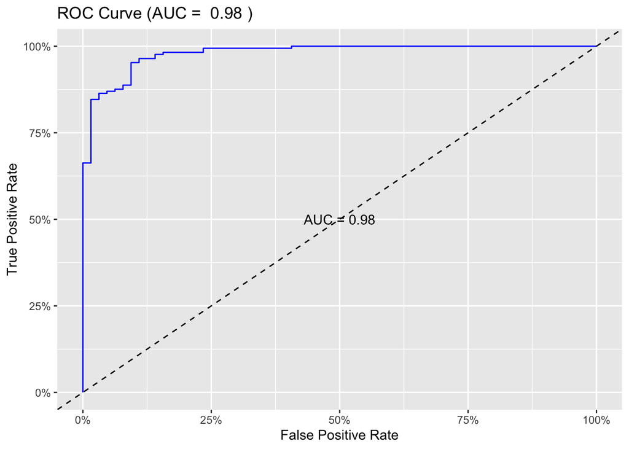

```r
ggroc(roc, color = "blue", legacy.axes = TRUE) +
  geom_abline(intercept = 0, slope = 1, linetype = "dashed") +
  scale_x_continuous(labels = scales::percent_format()) +
  scale_y_continuous(labels = scales::percent_format()) +
  labs(x = "False Positive Rate", y = "True Positive Rate",
       title = paste("ROC Curve (AUC = ", round(auc, 2), ")")) +
  annotate("text", x = 0.5, y = 0.5, label = paste0("AUC = ", round(auc, 2)))
```

- The plot above shows the ROC curve with an AUC of 98% which suggests that our prediction is good.